# VCaP

Tim Lai

5/5/2020

## Load the libraries

```r
#library("Rsubread")
library("DESeq2")
library("apeglm")
library("pheatmap")
library("RColorBrewer")
```

At some point, we should try running subread through R. This would eliminate the intermediate step of saving the count matrix file, as we could load it directly into DESeq2.

## Get counts

```r
df <- read.delim("counts.tsv", comment.char = "#")
cts <- df[(ncol(df)-3):ncol(df)]
rownames(cts) <- df$Geneid
rows <- colnames(cts)
condition <- c("Empty", "Empty", "ERG", "ERG")
coldata <- data.frame(condition, row.names = rows)
dds <- DESeqDataSetFromMatrix(countData = cts,
                              colData = coldata,
                              design = ~ condition)
```

## Do DGE

```r
dds <- DESeq(dds)
res <- results(dds)
res
```

```
## log2 fold change (MLE): condition ERG vs Empty
## Wald test p-value: condition ERG vs Empty
## DataFrame with 60617 rows and 6 columns
##                          baseMean     log2FoldChange              lfcSE
##                         <numeric>          <numeric>          <numeric>
## ENSG00000223972 0.268948614034363  -1.72240312411547   4.99592703229125
## ENSG00000227232 0.925327807400995   1.26943221247896   3.14086675778078
## ENSG00000278267  5.84642806156965  0.147021341229251   1.27346557375242
## ENSG00000243485                 0                 NA                 NA
## ENSG00000284332                 0                 NA                 NA
## ...                           ...                ...                ...
## ENSG00000198695  3486.30983390457 -0.238738572060901 0.0649901879904161
## ENSG00000210194  18.5963741525052 -0.866599978782752  0.712507189453954
## ENSG00000198727  67350.6694174317  0.106906329771919  0.165306062968694
## ENSG00000210195  158.163176524006  0.944449023046881  0.284079998302545
## ENSG00000210196  34.6570414421589   -1.5555301909688  0.567061744281108
##                              stat               pvalue                 padj
##                         <numeric>            <numeric>            <numeric>
## ENSG00000223972 -0.34476146528616    0.730273705116609                   NA
## ENSG00000227232 0.404166209640772    0.686090499878204                   NA
## ENSG00000278267 0.115449796413447    0.908088610965459    0.948978072022184
## ENSG00000243485                NA                   NA                   NA
## ENSG00000284332                NA                   NA                   NA
## ...                           ...                  ...                  ...
## ENSG00000198695 -3.67345563142712 0.000239292242952516 0.000849554303890078
## ENSG00000210194  -1.2162683992661    0.223882695286991     0.36456653832738
## ENSG00000198727  0.64671753625979    0.517814771454061    0.671882466540621
## ENSG00000210195   3.3245882451782 0.000885492055463771  0.00284122762732487
## ENSG00000210196 -2.74314077198211  0.00608545911671081   0.0165545667932751
```

## Analyze Results

### Results Description

```r
mcols(res)$description
```

```
## [1] "mean of normalized counts for all samples"
## [2] "log2 fold change (MLE): condition ERG vs Empty"
## [3] "standard error: condition ERG vs Empty"
## [4] "Wald statistic: condition ERG vs Empty"
## [5] "Wald test p-value: condition ERG vs Empty"
## [6] "BH adjusted p-values"
```

### LFC Estimates

```r
resLFC <- lfcShrink(dds, coef="condition_ERG_vs_Empty", type="apeglm")
```

```
## using 'apeglm' for LFC shrinkage. If used in published research, please cite:
##     Zhu, A., Ibrahim, J.G., Love, M.I. (2018) Heavy-tailed prior distributions for
##     sequence count data: removing the noise and preserving large differences.
##     Bioinformatics. https://doi.org/10.1093/bioinformatics/bty895
```

```r
resLFC
```

```
## log2 fold change (MAP): condition ERG vs Empty
## Wald test p-value: condition ERG vs Empty
## DataFrame with 60617 rows and 5 columns
##                          baseMean      log2FoldChange              lfcSE
##                         <numeric>           <numeric>          <numeric>
## ENSG00000223972 0.268948614034363 -0.0304262712097926  0.542232846665563
## ENSG00000227232 0.925327807400995  0.0367803888414105  0.536387628567116
## ENSG00000278267  5.84642806156965  0.0231722563048278  0.499586945648269
## ENSG00000243485                 0                  NA                 NA
## ENSG00000284332                 0                  NA                 NA
## ...                           ...                 ...                ...
## ENSG00000198695  3486.30983390457  -0.235500107989102 0.0646427743165754
## ENSG00000210194  18.5963741525052  -0.357376873159423  0.516285978092485
## ENSG00000198727  67350.6694174317   0.104680946494801  0.158348745095832
## ENSG00000210195  158.163176524006   0.840398420020793  0.285525103574852
## ENSG00000210196  34.6570414421589   -1.16738305435726  0.610525386983045
##                               pvalue                 padj
##                            <numeric>            <numeric>
## ENSG00000223972    0.730273705116609                   NA
## ENSG00000227232    0.686090499878204                   NA
## ENSG00000278267    0.908088610965459    0.948978072022184
## ENSG00000243485                   NA                   NA
## ENSG00000284332                   NA                   NA
## ...                              ...                  ...
## ENSG00000198695 0.000239292242952516 0.000849554303890078
## ENSG00000210194    0.223882695286991     0.36456653832738
## ENSG00000198727    0.517814771454061    0.671882466540621
## ENSG00000210195 0.000885492055463771  0.00284122762732487
## ENSG00000210196  0.00608545911671081   0.0165545667932751
```

### p-values and adjusted p-values

```r
resOrdered <- res[order(res$pvalue),]
summary(res)
```

```
##
## out of 32392 with nonzero total read count
## adjusted p-value < 0.1
## LFC > 0 (up)       : 4867, 15%
## LFC < 0 (down)     : 5257, 16%
## outliers [1]       : 0, 0%
## low counts [2]     : 10785, 33%
## (mean count < 2)
## [1] see 'cooksCutoff' argument of ?results
## [2] see 'independentFiltering' argument of ?results
```

## Visualizations

### MA-plot

log2 fold changes: log(experimental) - log(control)

Points will be colored red if the adjusted p value is less than 0.1. Points which fall out of the window are plotted as open triangles pointing either up or down.

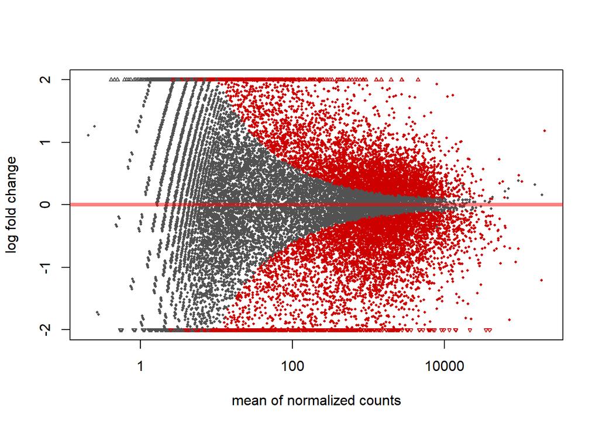

It is more useful visualize the MA-plot for the shrunken log2 fold changes, which remove the noise associated with log2 fold changes from low count genes without requiring arbitrary filtering thresholds.

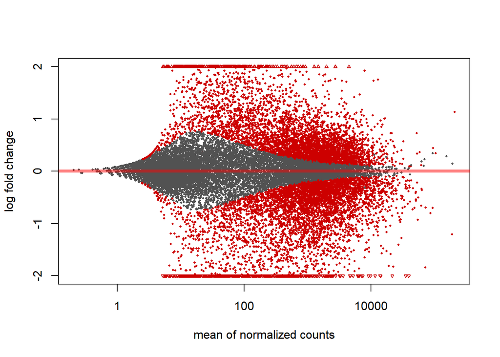

### Count Plot by Gene

It can also be useful to examine the counts of reads for a single gene across the groups. A simple function for making this plot is plotCounts, which normalizes counts by sequencing depth and adds a pseudocount of 1/2 to allow for log scale plotting. Here, the plot for the lowest p value gene is given.

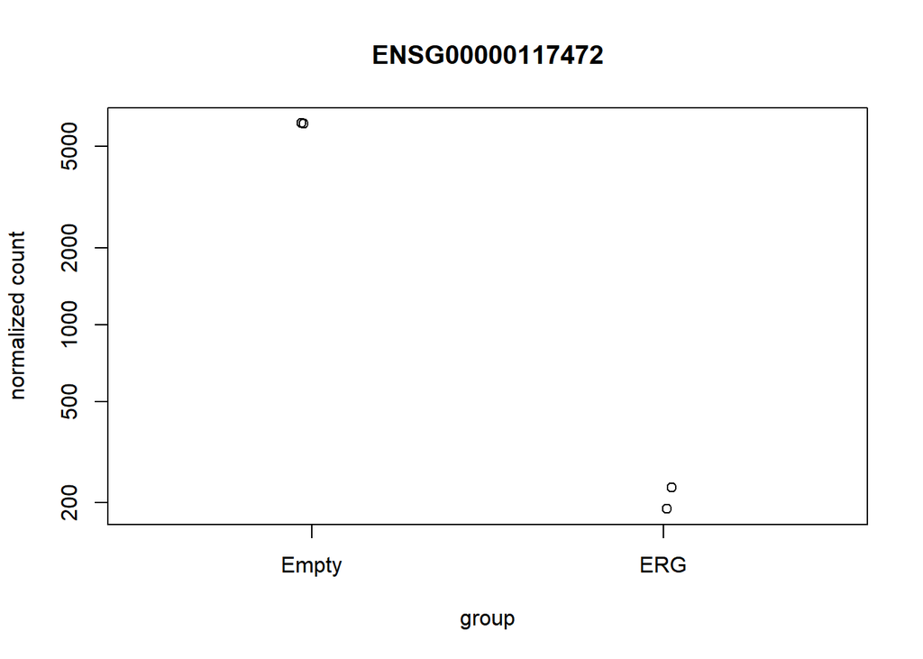

## Exporting Significant Results

First, order our p-values by the smallest.

```r
resOrdered <- res[order(res$pvalue),]
```

Now, filter out by p-value threshold and log2fc and export it as CSV.

```r
resSig <- subset(resOrdered, padj < 0.1)
resSig <- subset(resSig, abs(log2FoldChange) > 1)
write.csv(as.data.frame(resSig), file="condition_ERG_results.csv")
```

## Data Quality Assessment

### Count Matrix Heat Map

I produce a heatmap from the count matrix of the top 20 most expressed genes. The intent was a QC component to make sure that within each type, “Empty” and “ERG”, we see similar levels, which we do.

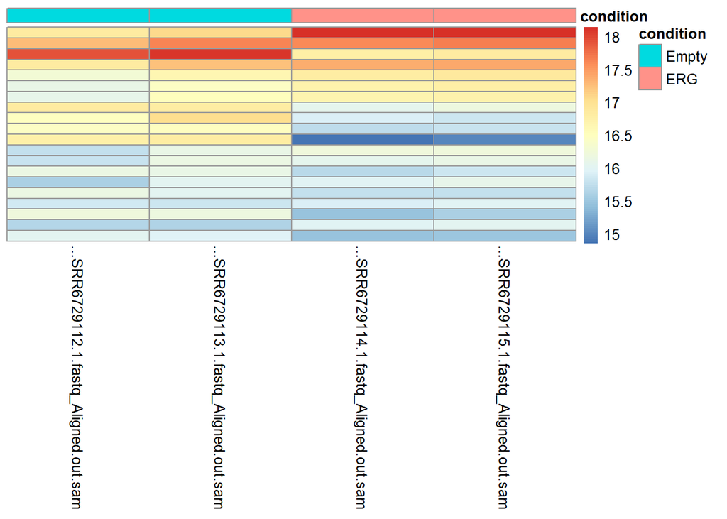

### Sample-to-Sample Distance Heatmap

The raw data may have been good for differential analysis. However, for applications such as clustering, we want some normalized values. DESeq2 provides some functions for this.

```r
vsd <- vst(dds, blind=FALSE)
head(assay(vsd), 3)
```

```
##                 ...SRR6729112.1.fastq_Aligned.out.sam
## ENSG00000223972                              10.16791
## ENSG00000227232                              10.16791
## ENSG00000278267                              10.27828
##                 ...SRR6729113.1.fastq_Aligned.out.sam
## ENSG00000223972                              10.21203
## ENSG00000227232                              10.21203
## ENSG00000278267                              10.25614
##                 ...SRR6729114.1.fastq_Aligned.out.sam
## ENSG00000223972                              10.16791
## ENSG00000227232                              10.22232
## ENSG00000278267                              10.23455
##                 ...SRR6729115.1.fastq_Aligned.out.sam
## ENSG00000223972                              10.16791
## ENSG00000227232                              10.21022
## ENSG00000278267                              10.30165
```

Now, we use this to provide a metric for sample-to-sample distance.

```r
sampleDists <- dist(t(assay(vsd)))
```

Visualize the distance matrix with a heatmap based on hierarchical clustering of sample distances

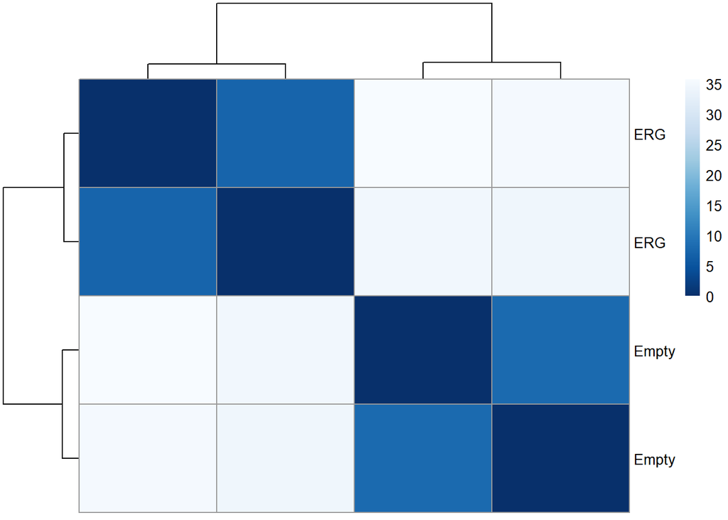

### PCA Plot

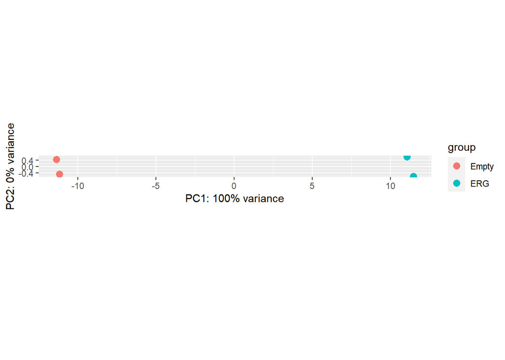